# hw5_code

```python
import pandas as pd
import numpy as np

raw = pd.read_csv("boston.txt", sep=r"\s+", skiprows=22, header=None)
X = np.hstack([raw.values[::2, :], raw.values[1::2, :2]])
y = raw.values[1::2, 2]
columns = [ "crim", "zn", "indus", "chas", "nox", "rm", "age",
"dis", "rad", "tax", "ptratio", "b", "lstat"]
df = pd.DataFrame(X, columns=columns)
df["medv"] = y
```

## a

```
                            OLS Regression Results
==============================================================================
Dep. Variable:                   medv   R-squared:                       0.563
Model:                            OLS   Adj. R-squared:                  0.561
Method:                 Least Squares   F-statistic:                     323.4
Date:                Fri, 13 Feb 2026   Prob (F-statistic):           4.93e-91
Time:                        12:22:43   Log-Likelihood:                -1631.1
No. Observations:                 506   AIC:                             3268.
Df Residuals:                     503   BIC:                             3281.
Df Model:                           2
Covariance Type:            nonrobust
==============================================================================
                 coef    std err          t      P>|t|      [0.025      0.975]
------------------------------------------------------------------------------
const         34.0941      0.561     60.809      0.000      32.993      35.196
lstat         -0.9406      0.038    -24.729      0.000      -1.015      -0.866
chas           4.9200      1.069      4.601      0.000       2.819       7.021
==============================================================================
Omnibus:                      131.896   Durbin-Watson:                   0.975
Prob(Omnibus):                  0.000   Jarque-Bera (JB):              275.510
Skew:                           1.406   Prob(JB):                     1.49e-60
Kurtosis:                       5.272   Cond. No.                         57.8
==============================================================================

Notes:
[1] Standard Errors assume that the covariance matrix of the errors is correctly specified.
```

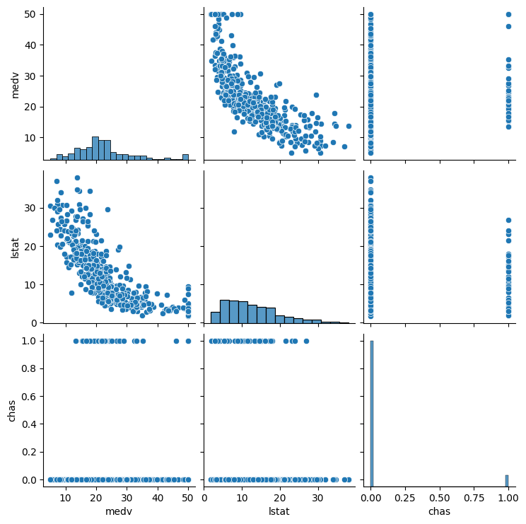

```python
import matplotlib.pyplot as plt
from seaborn import pairplot
import statsmodels.api as sm

pairplot(df[["medv", "lstat", "chas"]])
X = sm.add_constant(df[["lstat", "chas"]])
model = sm.OLS(df["medv"], X).fit()
print(model.summary())
```

The pair plots indicate a non linear relationship between `lstat` and `medv`, `medv` drops quickly for low-mid `lstat`, and then flattens out. Usually taking the log, square root, or inverse of `lstat` can help fix this. For this problem, we will use a log transformation.

**Intercept**: 34.0941, SE 0.561, p < 0.0001  
This is the predicted `medv` for an `lstat` and `chas` value of 0. This isn't meaningful realistically as `lstat` 0 isn't possible, but this anchors the regression line. The value is statistically significant and well estimated from the low SE and p value.

**`lstat` coefficient**: -0.9406, SE 0.038, p < 0.0001  
Holding `chas` constant, a 1 percentage point increase in `lstat` is attributed to about a $940.6 decrease in `medv`. The value is statistically significant and well estimated from the low SE and p value.

**`chas` coefficient**: 4.92, SE 1.069, p < 0.0001 Holding `lstat` constant, properties that border the Charles River are attributed to a $4,920 increase in `medv`. The value is statistically significant and well estimated from the low SE and p value.

```
                            OLS Regression Results
==============================================================================
Dep. Variable:                   medv   R-squared:                       0.678
Model:                            OLS   Adj. R-squared:                  0.677
Method:                 Least Squares   F-statistic:                     530.1
Date:                Fri, 13 Feb 2026   Prob (F-statistic):          1.43e-124
Time:                        12:22:54   Log-Likelihood:                -1553.4
No. Observations:                 506   AIC:                             3113.
Df Residuals:                     503   BIC:                             3125.
Df Model:                           2
Covariance Type:            nonrobust
==============================================================================
                 coef    std err          t      P>|t|      [0.025      0.975]
------------------------------------------------------------------------------
const         51.5250      0.956     53.899      0.000      49.647      53.403
log_lstat    -12.3500      0.388    -31.814      0.000     -13.113     -11.587
chas           4.1819      0.918      4.554      0.000       2.378       5.986
==============================================================================
Omnibus:                      126.805   Durbin-Watson:                   0.990
Prob(Omnibus):                  0.000   Jarque-Bera (JB):              335.582
Skew:                           1.230   Prob(JB):                     1.35e-73
Kurtosis:                       6.140   Cond. No.                         11.9
==============================================================================

Notes:
[1] Standard Errors assume that the covariance matrix of the errors is correctly specified.
```

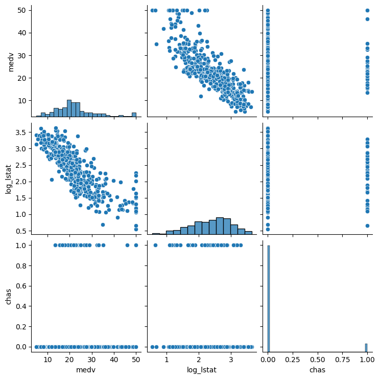

```python
df["log_lstat"] = np.log(df["lstat"])
pairplot(df[["medv", "log_lstat", "chas"]])
X = sm.add_constant(df[["log_lstat", "chas"]])
model = sm.OLS(df["medv"], X).fit()
print(model.summary())
```

**Intercept**: 51.5250, SE 0.956, p < 0.0001  
This is the predicted `medv` for an `lstat` and `chas` value of 0. This isn't meaningful realistically as `lstat` 0 isn't possible, but this anchors the regression line. The value is statistically significant and well estimated from the low SE and p value.

**`log_lstat` coefficient**: -12.3500, SE 0.388, p < 0.0001  
Holding `chas` constant, a 1 percentage point increase in `lstat` is attributed to about a $123.50 decrease in `medv`. The value is statistically significant and well estimated from the low SE and p value.

The adjusted R^2 of the model is much higher than the original model, already showing an improvement. From the pairplot, we can see the relationship between `log_lstat` and `medv` is linear now, showing the log transformation helped.

## b

```python
df["loglstat_chas"] = df["log_lstat"] * df["chas"]
X = sm.add_constant(df[["log_lstat", "chas", "loglstat_chas"]])
model_interaction = sm.OLS(df["medv"], X).fit()
print(model_interaction.summary())
```

```
                            OLS Regression Results
==============================================================================
Dep. Variable:                   medv   R-squared:                       0.680
Model:                            OLS   Adj. R-squared:                  0.678
Method:                 Least Squares   F-statistic:                     354.8
Date:                Fri, 13 Feb 2026   Prob (F-statistic):          1.35e-123
Time:                        12:22:57   Log-Likelihood:                -1552.4
No. Observations:                 506   AIC:                             3113.
Df Residuals:                     502   BIC:                             3130.
Df Model:                           3
Covariance Type:            nonrobust
=================================================================================
                    coef    std err          t      P>|t|      [0.025      0.975]
---------------------------------------------------------------------------------
const            51.0995      1.000     51.075      0.000      49.134      53.065
log_lstat       -12.1715      0.408    -29.868      0.000     -12.972     -11.371
chas              8.3909      3.090      2.715      0.007       2.320      14.462
loglstat_chas    -1.8922      1.327     -1.426      0.154      -4.498       0.714
==============================================================================
Omnibus:                      128.919   Durbin-Watson:                   1.002
Prob(Omnibus):                  0.000   Jarque-Bera (JB):              351.383
Skew:                           1.239   Prob(JB):                     4.99e-77
Kurtosis:                       6.245   Cond. No.                         38.2
==============================================================================

Notes:
[1] Standard Errors assume that the covariance matrix of the errors is correctly specified.
```

**Intercept**: 51.0995, SE 1, p < 0.0001  
This is the predicted `medv` for an `lstat` and `chas` value of 0. This isn't meaningful realistically as `lstat` 0 isn't possible, but this anchors the regression line. The value is statistically significant and well estimated from the low SE and p value.

**`log_lstat` coefficient**: -12.1715, SE 0.408, p < 0.0001  
Holding `chas` constant, a 1 percentage point increase in `lstat` is attributed to about a $121.72 decrease in `medv`. The value is statistically significant and well estimated from the low SE and p value. The coefficient is slightly smaller than the model without the interaction term.

Given that the new R squared value of this model 0.680 is barely an improvement from the previous model of 0.678, and the interaction term is not statistically significat, interactions do not improve the model.

## c

```python
df0 = df[df["chas"] == 0]
df1 = df[df["chas"] == 1]

X0 = sm.add_constant(df0["log_lstat"])
model0 = sm.OLS(df0["medv"], X0).fit()
print(model0.summary())

X1 = sm.add_constant(df1["log_lstat"])
model1 = sm.OLS(df1["medv"], X1).fit()
print(model1.summary())
```

```
                            OLS Regression Results
==============================================================================
Dep. Variable:                   medv   R-squared:                       0.664
Model:                            OLS   Adj. R-squared:                  0.663
Method:                 Least Squares   F-statistic:                     925.6
Date:                Fri, 13 Feb 2026   Prob (F-statistic):          4.68e-113
Time:                        12:23:00   Log-Likelihood:                -1437.2
No. Observations:                 471   AIC:                             2878.
Df Residuals:                     469   BIC:                             2887.
Df Model:                           1
Covariance Type:            nonrobust
==============================================================================
                 coef    std err          t      P>|t|      [0.025      0.975]
------------------------------------------------------------------------------
const         51.0995      0.982     52.025      0.000      49.169      53.030
log_lstat    -12.1715      0.400    -30.424      0.000     -12.958     -11.385
==============================================================================
Omnibus:                      127.277   Durbin-Watson:                   0.996
Prob(Omnibus):                  0.000   Jarque-Bera (JB):              347.256
Skew:                           1.306   Prob(JB):                     3.93e-76
Kurtosis:                       6.297   Cond. No.                         11.8
==============================================================================

Notes:
[1] Standard Errors assume that the covariance matrix of the errors is correctly specified.
                            OLS Regression Results
==============================================================================
Dep. Variable:                   medv   R-squared:                       0.713
Model:                            OLS   Adj. R-squared:                  0.704
Method:                 Least Squares   F-statistic:                     81.96
Date:                Fri, 13 Feb 2026   Prob (F-statistic):           1.84e-10
Time:                        12:23:00   Log-Likelihood:                -113.75
No. Observations:                  35   AIC:                             231.5
Df Residuals:                      33   BIC:                             234.6
Df Model:                           1
Covariance Type:            nonrobust
==============================================================================
                 coef    std err          t      P>|t|      [0.025      0.975]
------------------------------------------------------------------------------
const         59.4904      3.598     16.536      0.000      52.171      66.810
log_lstat    -14.0637      1.553     -9.053      0.000     -17.224     -10.903
==============================================================================
Omnibus:                        9.133   Durbin-Watson:                   1.242
Prob(Omnibus):                  0.010   Jarque-Bera (JB):               10.478
Skew:                           0.686   Prob(JB):                      0.00531
Kurtosis:                       5.303   Cond. No.                         8.99
==============================================================================

Notes:
[1] Standard Errors assume that the covariance matrix of the errors is correctly specified.
```

[output not shown]

Note that the slopes for each `chas` specific model are the same as the indicated slopes in the interaction model when accounting for the interaction term. Additionally, the `chas` = 1 model only has 35 samples. Thus, we prefer the original log `lstat` model due to it using all 506 observations, and more importantly, because the interaction term is not statistically significant, using a common slope reduces variance, increases efficiency (in future predictions), simplifies interpretation, and avoids overfitting the smaller group (`chas` = 1). We can see this already occurring as the R^2 for the `chas` = 1 model is higher.

## d

```python
df_restrict = df[df["rad"] <= 8]

X_num = sm.add_constant(df_restrict[["log_lstat", "rad"]].astype(float))
model_num = sm.OLS(df_restrict["medv"].astype(float), X_num).fit()
print(model_num.summary())

rad_dummies = pd.get_dummies(df_restrict["rad"], prefix="rad", drop_first=True)
X_cat = sm.add_constant(pd.concat([df_restrict["log_lstat"].astype(float), rad_dummies.astype(float)], axis=1))
model_cat = sm.OLS(df_restrict["medv"].astype(float), X_cat).fit()
print(model_cat.summary())
```

```
                            OLS Regression Results
==============================================================================
Dep. Variable:                   medv   R-squared:                       0.606
Model:                            OLS   Adj. R-squared:                  0.603
Method:                 Least Squares   F-statistic:                     284.8
Date:                Fri, 13 Feb 2026   Prob (F-statistic):           1.12e-75
Time:                        12:23:08   Log-Likelihood:                -1153.1
No. Observations:                 374   AIC:                             2312.
Df Residuals:                     371   BIC:                             2324.
Df Model:                           2
Covariance Type:            nonrobust
==============================================================================
                 coef    std err          t      P>|t|      [0.025      0.975]
------------------------------------------------------------------------------
const         48.4863      1.337     36.263      0.000      45.857      51.115
log_lstat    -11.6251      0.489    -23.757      0.000     -12.587     -10.663
rad            0.4140      0.168      2.462      0.014       0.083       0.745
==============================================================================
Omnibus:                       71.571   Durbin-Watson:                   0.945
Prob(Omnibus):                  0.000   Jarque-Bera (JB):              125.233
Skew:                           1.088   Prob(JB):                     6.40e-28
Kurtosis:                       4.816   Cond. No.                         26.9
==============================================================================

Notes:
[1] Standard Errors assume that the covariance matrix of the errors is correctly specified.
                            OLS Regression Results
==============================================================================
Dep. Variable:                   medv   R-squared:                       0.634
Model:                            OLS   Adj. R-squared:                  0.626
Method:                 Least Squares   F-statistic:                     78.89
Date:                Fri, 13 Feb 2026   Prob (F-statistic):           7.15e-75
Time:                        12:23:08   Log-Likelihood:                -1139.4
No. Observations:                 374   AIC:                             2297.
Df Residuals:                     365   BIC:                             2332.
Df Model:                           8
Covariance Type:            nonrobust
==============================================================================
                 coef    std err          t      P>|t|      [0.025      0.975]
------------------------------------------------------------------------------
const         46.2099      1.501     30.788      0.000      43.258      49.161
log_lstat    -11.2540      0.495    -22.715      0.000     -12.228     -10.280
rad_2.0        4.4640      1.563      2.857      0.005       1.391       7.537
rad_3.0        4.7632      1.425      3.344      0.001       1.962       7.565
rad_4.0        1.6991      1.270      1.338      0.182      -0.797       4.196
rad_5.0        4.3335      1.255      3.452      0.001       1.865       6.802
rad_6.0        2.4319      1.554      1.565      0.118      -0.624       5.488
rad_7.0        3.1987      1.700      1.881      0.061      -0.145       6.542
rad_8.0        5.9636      1.560      3.822      0.000       2.895       9.032
==============================================================================
Omnibus:                       77.028   Durbin-Watson:                   1.016
Prob(Omnibus):                  0.000   Jarque-Bera (JB):              143.714
Skew:                           1.131   Prob(JB):                     6.21e-32
Kurtosis:                       5.027   Cond. No.                         31.9
==============================================================================

Notes:
[1] Standard Errors assume that the covariance matrix of the errors is correctly specified.
```

| Model | n | R^2 | Adj R^2 | AIC | BIC |
| --- | --- | --- | --- | --- | --- |
| Numerical `rad` | 374 | 0.606 | 0.603 | 2312 | 2324 |
| Categorical `rad` | 374 | 0.634 | 0.626 | 2297 | 2332 |

## e

```python
b3 = model_cat.params["rad_3.0"]
b4 = model_cat.params["rad_4.0"]
diff = b3 - b4
print(f"Estimated difference in expected value of medv between houses w/ rad = 3 and rad = 4: {diff}")

cov = model_cat.cov_params()
var_diff = (
    cov.loc["rad_3.0", "rad_3.0"]
    + cov.loc["rad_4.0", "rad_4.0"]
    - 2 * cov.loc["rad_3.0", "rad_4.0"]
)
se_diff = np.sqrt(var_diff)
print(f"Estimated standard error of the difference: {se_diff}")
```

```
Estimated difference in expected value of medv between houses w/ rad = 3 and rad = 4: 3.0640954476181186
Estimated standard error of the difference: 0.9816951849191523
```